# BulsinkB xG Model

Philip Bulisnk

21/09/2020

# Intro

This document will outline the creating of a xG model for use in the BulsinkB model (see twitter.com/BulsinkB). This model bulding will use the tidymodels toolset and be based on excellent work by Matt Barlowe and Evolving Wild.

# Data

We’ll start by loading data using the tools in this package, then combining all but the most recent season’s data into one file:

```r
pbp2007<-readRDS("~/NHLpbp/2007.rds")
pbp2008<-readRDS("~/NHLpbp/2008.rds")
pbp2009<-readRDS("~/NHLpbp/2009.rds")
pbp2010<-readRDS("~/NHLpbp/2010.rds")
pbp2011<-readRDS("~/NHLpbp/2011.rds")
pbp2012<-readRDS("~/NHLpbp/2012.rds")
pbp2013<-readRDS("~/NHLpbp/2013.rds")
pbp2014<-readRDS("~/NHLpbp/2014.rds")
pbp2015<-readRDS("~/NHLpbp/2015.rds")
pbp2016<-readRDS("~/NHLpbp/2016.rds")
pbp2017<-readRDS("~/NHLpbp/2017.rds")
pbp2018<-readRDS("~/NHLpbp/2018.rds")
pbp2019<-readRDS("~/NHLpbp/2019.rds")

pbp<-dplyr::bind_rows(pbp2007, pbp2008, pbp2009, pbp2010, pbp2011, pbp2012, pbp2013, pbp2014, pbp2015, pbp2016, pbp2017, pbp2018)
pbp_test<-pbp2019

#Get rid of year files: we don't need them in memory anymore
rm(pbp2007, pbp2008, pbp2009, pbp2010, pbp2011, pbp2012, pbp2013, pbp2014, pbp2015, pbp2016, pbp2017, pbp2018, pbp2019)
```

Note that we’ll use 2019 (current season) data as the test to see how well the model predicts. How much data do we have? The number of events in the training (2007 - 2018) data is 9378551 and the number of rows in the testing 2019 data is 761932

Now some more shortcut prep:

```r
fenwick_events <- c('SHOT', 'MISS', 'GOAL')
corsi_events <- c('SHOT', 'MISS', 'GOAL', 'BLOCK')
```

## Data Munching

We’ll use Fenwick data here: the NHL PBP doesn’t provide the shooter location on a shot-block event. So we’ll start paring down the data. Note that we’re also selecting the immediately preceding event for some feature testing down the road.

```r
pbp<-pbp %>%
  filter(coords_x != 'NA' & coords_y != "NA" & event_detail != "NA" & event_team != "NA") %>%
  filter(event_type %in% fenwick_events | dplyr::lag(event_type %in% fenwick_events)) %>%
  select(-c(session, event_zone, event_length, num_on, num_off, players_on, players_off, game_score_state, game_strength_state))

pbp_test<-pbp_test %>%
  filter(coords_x != 'NA' & coords_y != "NA" & event_detail != "NA" & event_team != "NA") %>%
  filter(event_type %in% fenwick_events | dplyr::lag(event_type %in% fenwick_events)) %>%
  select(-c(session, event_zone, event_length, num_on, num_off, players_on, players_off, game_score_state, game_strength_state))
```

That has quickly reduced our data size: we now have 1600581 training rows and 132154 test rows.

We’ll now move on by adding a bunch of data columns (and maybe dropping a few too). This feature addition is not changing the data, but just re-phrasing it in a way that a model can use it to make predictions. This is where the ‘art’ of data science lives.

```r
prep_data<-function(data){
  data<- data %>%
    mutate(is_home = if_else(event_team == home_team, 1, 0),  # binary home team event factor
           is_goal = if_else(event_type == "GOAL", 1, 0),  # binary is goal factor
           x_coord = abs(coords_x),  # absolute x coordinate - put home and away on same side of ice
           y_coord = if_else(coords_x < 0, coords_y * -1, coords_y)) %>%  # absolute y coordinate - for calculations
  #calculate time_diff but only use the game, don't revert to previous game in data stack
    group_by(game_id) %>%
      arrange(event_index, .by_group = TRUE) %>%
      mutate(time_diff = game_seconds - dplyr::lag(game_seconds)) %>%  # calculate time from previous event
    ungroup() %>%
    mutate(time_diff = if_else(is.na(time_diff), 100, time_diff),  # fix any NA results - 100 s will have such low impact on values.
           time_diff = if_else(time_diff < 0, 1000, time_diff)) %>%  # <0 time diff makes no sense, bump it to the psudo na value of 100 s
    mutate(is_rebound = if_else(time_diff < 3 & event_type %in% fenwick_events & dplyr::lag(event_type) %in% corsi_events & event_team == dplyr::lag(event_team), 1, 0),  # is this a rebound shot?
           is_rush = if_else(time_diff < 4 & abs(dplyr::lag(coords_x)) < 25, 1, 0),  # does this look like a shot on a rush?
           speed = if_else(!is.na(time_diff), sqrt((coords_x-dplyr::lag(coords_x))^2 + (coords_y - dplyr::lag(coords_y))^2)/time_diff, 0),  # speed from previous event to shot location in m/s
           shot_side = if_else((coords_x < 0 & coords_y < 0) | (coords_x > 0 & coords_y > 0), 'right', 'left'),  # from which side (goalie view) the fenwick comes from
           cross_ice = if_else(shot_side == dplyr::lag(shot_side), 1, 0)) %>%  # if shot comes from opposite side of previous event
  #Fixing any NA results or other illogicals
    mutate(is_rush = if_else(is.na(is_rush), 0, is_rush),
           is_rebound = if_else(is.na(is_rebound), 0, is_rebound),
           is_cluster = if_else(lag(is_rebound)==1 & is_rebound == 1, 1, 0),
           speed = if_else(is.na(speed), 0, speed),
           speed = if_else(is.infinite(speed), 0, speed),
           shot_side = if_else(is.na(shot_side), 'middle', shot_side),
           cross_ice = if_else(is.na(cross_ice), 0, cross_ice),
           #pbp_distance from EW
           pbp_distance = suppressWarnings(as.numeric(sub(".*Zone, *(.*?) * ft.*", "\\1", event_description))),
           #event_zone from EW
           event_zone = ifelse((grepl("off. zone", tolower(event_description)) == TRUE), "Off",
                                 ifelse((grepl("neu. zone", tolower(event_description)) == TRUE), "Neu",
                                        ifelse((grepl("def. zone", tolower(event_description)) == TRUE), "Def",
                                               NA))),
           event_zone = ifelse(event_zone == "Def" & event_type == "BLOCK", "Off", event_zone),
           event_zone = ifelse(event_type %in% fenwick_events & event_zone == "Def" & pbp_distance <= 64, "Off", event_zone)) %>%
  #We've done our manipulations using the lagged data, go to fenwick only data now (and drop shootout attempts for which game_seconds == 3900)
    filter(event_type %in% fenwick_events & game_seconds != 3900) %>%
    mutate(shot_angle = if_else(abs(coords_y) < 3, 0, if_else(coords_y > 0,
                                                              abs(atan((coords_y - 3) / (89 - abs(coords_x))) * (180 / pi)),
                                                              abs(atan((coords_y + 3) / (89 - abs(coords_x))) * (180 / pi)))),# angle to the closest post if outside

           shot_distance = sqrt((89 - abs(coords_x))^2 + coords_y^2) # distance to the center of the goal mouth TODO: change to nearest post
           ) %>%
    mutate(# Update distance calc for long shots (and various mistakes) from EW
           shot_distance = if_else(pbp_distance > 89 & event_detail != "Wrap-around" & event_detail != "Tip-In" & event_detail != "Deflected" & !(pbp_distance > 89 & event_zone == "Off"),
                                    sqrt((abs(coords_x) + 89)^2 + coords_y^2), shot_distance),
           shot_angle = if_else(pbp_distance > 89 & event_detail != "Tip-In" & event_detail !="Wrap-around" & event_detail != "Deflected" & !(pbp_distance > 89 & event_zone == "Off"),
                                  abs(atan(coords_y / (abs(coords_x) + 89)) * (180 / pi)), shot_angle),
           event_zone = ifelse(event_zone == "Def" & pbp_distance <= 64, "Off", event_zone))%>%
    mutate(shot_angle = if_else(x_coord >= 89, 90 + shot_angle,shot_angle)) %>% # fix angles for behind-net shots
    mutate(attacker_benefit = if_else(is_home == 1, home_skaters - away_skaters, away_skaters - home_skaters),  # Does the shooting team have more or less players on ice?
           #extra_attacker = if_else((is_home & home_skaters > away_skaters) | (!is_home & away_skaters > home_skaters), 1, 0),
           #shorthanded = if_else((is_home & home_skaters < away_skaters) | (!is_home & away_skaters < home_skaters), 1, 0),
           shooter_net_empty = if_else((is_home == 1 & is.na(home_goalie)) | (!is_home == 1 & is.na(away_goalie)), 1, 0),  # Is the shooter's goalie pulled?
           target_net_empty = if_else((is_home == 1 & is.na(away_goalie)) | (!is_home == 1 & is.na(home_goalie)), 1, 0),  # Is the target goalie pulled?
           shooter_gd = if_else(is_home == 1, home_score - away_score, away_score - home_score),# What's the score impact?
           shooter_goal_differential = case_when(shooter_gd <= -5 ~ "-5+",
                                                 shooter_gd == -4 ~ "-4",
                                                 shooter_gd == -3 ~ "-3",
                                                 shooter_gd == -2 ~ "-2",
                                                 shooter_gd == -1 ~ "-1",
                                                 shooter_gd == 0 ~ "0",
                                                 shooter_gd == 1 ~ "+1",
                                                 shooter_gd == 2 ~ "+2",
                                                 shooter_gd == 3 ~ "+3",
                                                 shooter_gd == 4 ~ "+4",
                                                 shooter_gd >=5 ~ "+5+",
                                                 TRUE ~ "UNK")
           ) %>%
    mutate(result = factor(is_goal, c(0,1), c('no_goal', 'goal')))  # %>%
    #select(season, game_id, game_period, event_type, event_detail, event_team, event_player_1, coords_x, coords_y, home_team, away_team, home_skaters, away_skaters, home_score, away_score, is_home, is_goal, x_coord, y_coord, time_diff, is_rebound, is_rush, speed, shot_side, cross_ice, is_cluster, pbp_distance, event_zone, shot_angle, shot_distance, attacker_benefit, shooter_net_empty, target_net_empty, shooter_goal_differential)
  return(data)
}

pbp <- pbp %>% prep_data()
pbp_test <- pbp_test %>% prep_data()
```

# Modelling

We’ll be using the tidymodels package in R to do the actual modeling. There are a few more things to do with the data to prepare it for tidymodels. Now we’ll split the data randomly into in-sample test & train sets, then prepare the general recipe (or formula) that we want to feed into the model.

```r
library(tidymodels)
set.seed(seed = 2007)

train_test_split <- initial_split(data = pbp, prop = 0.75)

train_data<-train_test_split %>% training()
test_data<-train_test_split %>% testing()

model_recipe <-
  recipe(result ~ shot_distance + shot_angle + event_detail + is_rebound + is_rush + is_cluster +
                   shooter_net_empty + target_net_empty + speed + attacker_benefit + event_zone +
                   shooter_goal_differential + shot_side + cross_ice + x_coord + y_coord,
         data = train_data) %>%
  update_role(x_coord, y_coord, new_role = "ID") %>%
  step_string2factor(event_detail, event_zone, shot_side, shooter_goal_differential) %>%
  step_num2factor(is_rebound, transform = function(x) x+1, levels = c("no", "yes")) %>%
  step_num2factor(is_rush, transform = function(x) x+1, levels = c("no", "yes")) %>%
  step_num2factor(shooter_net_empty, transform = function(x) x+1, levels = c("no", "yes")) %>%
  step_num2factor(target_net_empty,transform = function(x) x+1, levels = c("no", "yes")) %>%
  step_num2factor(cross_ice, transform = function(x) x+1, levels = c("no", "yes")) %>%
  step_num2factor(is_cluster,transform = function(x) x+1, levels = c("no", "yes")) %>%
  step_zv(all_predictors())

summary(model_recipe)
```

```
## # A tibble: 17 x 4
##    variable                  type    role      source
##    <chr>                     <chr>   <chr>     <chr>
##  1 shot_distance             numeric predictor original
##  2 shot_angle                numeric predictor original
##  3 event_detail              nominal predictor original
##  4 is_rebound                numeric predictor original
##  5 is_rush                   numeric predictor original
##  6 is_cluster                numeric predictor original
##  7 shooter_net_empty         numeric predictor original
##  8 target_net_empty          numeric predictor original
##  9 speed                     numeric predictor original
## 10 attacker_benefit          numeric predictor original
## 11 event_zone                nominal predictor original
## 12 shooter_goal_differential nominal predictor original
## 13 shot_side                 nominal predictor original
## 14 cross_ice                 numeric predictor original
## 15 x_coord                   numeric ID        original
## 16 y_coord                   numeric ID        original
## 17 result                    nominal outcome   original
```

Now we can define our model (this is the bit that is changeable) then feed that design into the modeling workflow. Then wqe fit it.

```r
model <- logistic_reg() %>%
  set_engine('glm')

xg_wflow<-workflow() %>%
  add_model(model) %>%
  add_recipe(model_recipe)

#xg_wflow

xg_fit <- xg_wflow %>%
  fit(data = train_data)

xg_fit %>%
  pull_workflow_fit() %>%
  tidy()
```

```
## # A tibble: 30 x 5
##    term                    estimate std.error statistic   p.value
##    <chr>                      <dbl>     <dbl>     <dbl>     <dbl>
##  1 (Intercept)               1.77    0.0731      24.2   7.43e-130
##  2 shot_distance            -0.0475  0.000364  -130.    0.
##  3 shot_angle               -0.0143  0.000230   -62.1   0.
##  4 event_detailDeflected     0.0116  0.0291       0.400 6.89e-  1
##  5 event_detailSlap          0.654   0.0209      31.3   2.14e-214
##  6 event_detailSnap          0.602   0.0187      32.3   2.95e-228
##  7 event_detailTip-In        0.0603  0.0202       2.98  2.86e-  3
##  8 event_detailWrap-around  -0.558   0.0494     -11.3   1.23e- 29
##  9 event_detailWrist         0.326   0.0158      20.7   4.69e- 95
## 10 is_reboundyes             0.851   0.0155      54.9   0.
## # ... with 20 more rows
```

```r
# https://juliasilge.com/blog/xgboost-tune-volleyball/
xgb_spec <- boost_tree(
  trees = 1000,
  tree_depth = tune(), min_n = tune(),
  loss_reduction = tune(),                     ## first three: model complexity
  sample_size = tune(), mtry = tune(),         ## randomness
  learn_rate = tune(),                         ## step size
) %>%
  set_engine("xgboost") %>%
  set_mode("regression")

xgb_grid <- grid_latin_hypercube(
  tree_depth(),
  min_n(),
  loss_reduction(),
  sample_size = sample_prop(),
  finalize(mtry(), vb_train),
  learn_rate(),
  size = 30
)

xgb_wf <- workflow() %>%
  add_model(xgb_spec) %>%
  add_recipe(model_recipe)

xg_folds <- vfold_cv(train_data, strata = result)

doParallel::registerDoParallel()

set.seed(234)
xgb_res <- tune_grid(
  xgb_wf,
  resamples = xg_folds,
  grid = xgb_grid,
  control = control_grid(save_pred = TRUE)
)

show_best(xgb_res, "roc_auc")

best_auc <- select_best(xgb_res, "roc_auc")

final_xgb <- finalize_workflow(
  xgb_wf,
  best_auc
)

final_res <- last_fit(final_xgb, train_test_split)

collect_metrics(final_res)
```

# Checking Model Output Does it make sense?

We’ve saved some data that we can use to test the predictor with.

```r
pbp_test$xG <- predict(xg_fit, pbp_test, type = "prob")$.pred_goal

avg_xG_by_coord <- pbp_test %>% group_by(x_coord, y_coord) %>%
    summarise(xg = mean(xG))
```

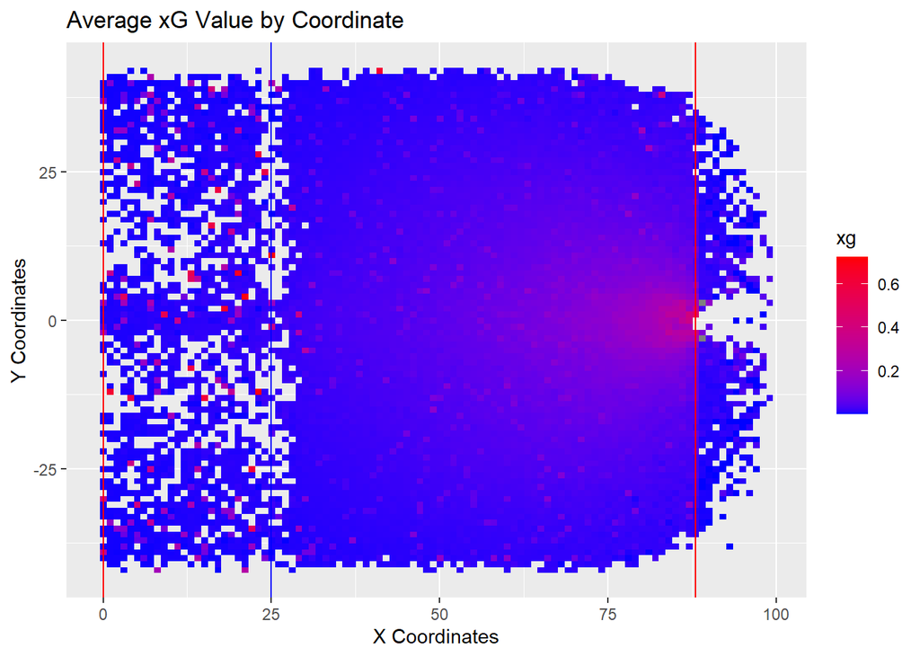

```r
ggplot(avg_xG_by_coord, aes(x_coord, y_coord, fill = xg)) + geom_raster() +
    scale_fill_gradient(low = 'blue', high = 'red')+
    geom_vline(xintercept = 0, color = 'red') +
    geom_vline(xintercept = 25, color = 'blue') +
    geom_vline(xintercept = 88, color = 'red') +
    xlab('X Coordinates') + ylab('Y Coordinates') +
    labs(title = 'Average xG Value by Coordinate')
```

We’ll do some ‘goodness of prediction’ work now:

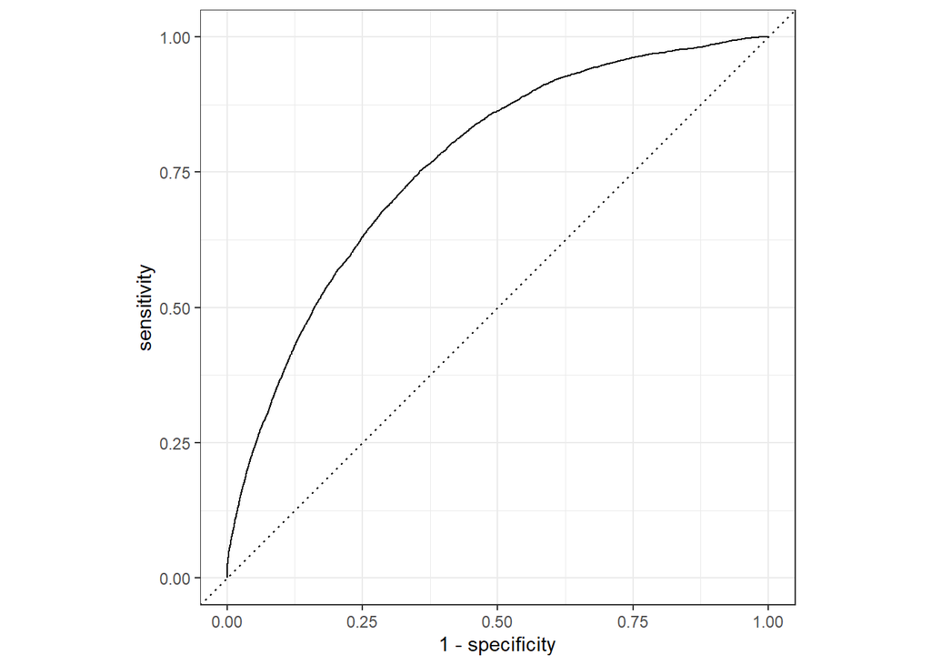

```r
pbp_test %>% roc_curve(result, xG, event_level = 'second') %>% autoplot()
```

# Look at the Data

Lets take a look at the data from the test year: First player lists

```r
xg_player <- pbp_test %>%
    group_by(event_player_1, event_team) %>%
    summarise( xG = sum(xG), Goals = sum(is_goal), Difference = sum(xG) - sum(is_goal)) %>%
    arrange(desc(xG))
head(xg_player)
```

```
## # A tibble: 6 x 5
## # Groups:   event_player_1 [6]
##   event_player_1 event_team    xG Goals Difference
##   <chr>          <chr>      <dbl> <dbl>      <dbl>
## 1 ALEX.OVECHKIN  WSH         35.4    52    -16.6
## 2 ANDERS.LEE     NYI         35.1    26      9.09
## 3 MAX.PACIORETTY VGK         32.9    37     -4.06
## 4 BRADY.TKACHUK  OTT         32.3    19     13.3
## 5 KYLE.CONNOR    WPG         31.9    38     -6.11
## 6 BO.HORVAT      VAN         31.2    32     -0.775
```

```r
player_xg <- lm(Goals ~ xG, data = xg_player)
summary(player_xg)
```

```
##
## Call:
## lm(formula = Goals ~ xG, data = xg_player)
##
## Residuals:
##      Min       1Q   Median       3Q      Max
## -16.5839  -1.2397   0.0706   0.9479  20.0218
##
## Coefficients:
##             Estimate Std. Error t value Pr(>|t|)
## (Intercept) -0.49125    0.13875  -3.541 0.000419 ***
## xG           1.11558    0.01366  81.674  < 2e-16 ***
## ---
## Signif. codes:  0 '***' 0.001 '**' 0.01 '*' 0.05 '.' 0.1 ' ' 1
##
## Residual standard error: 3.106 on 949 degrees of freedom
##   (4 observations deleted due to missingness)
## Multiple R-squared:  0.8755, Adjusted R-squared:  0.8753
## F-statistic:  6671 on 1 and 949 DF,  p-value: < 2.2e-16
```

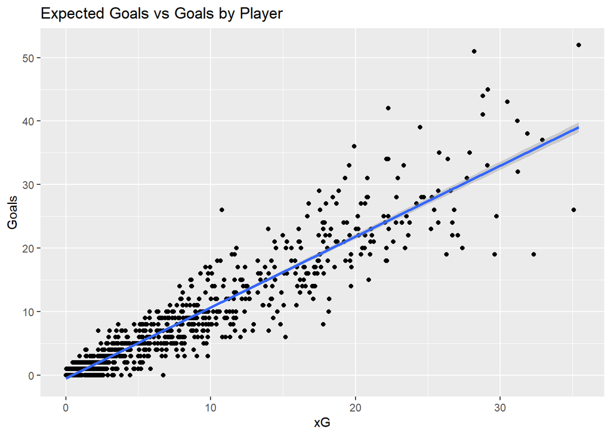

```r
ggplot(aes(x = xG, y = Goals), data = xg_player) +
    geom_point() +
    geom_smooth(method = 'lm') +
    labs(title = 'Expected Goals vs Goals by Player')
```

Next, the same by team:

```r
xg_team <- pbp_test %>%
    group_by(event_team) %>%
    summarise(xG = sum(xG), Goals = sum(is_goal), Difference = sum(xG) - sum(is_goal)) %>%
    arrange(desc(xG))
head(xg_team)
```

```
## # A tibble: 6 x 4
##   event_team    xG Goals Difference
##   <chr>      <dbl> <dbl>      <dbl>
## 1 VGK         301.   280     21.3
## 2 T.B         286.   318    -31.8
## 3 DAL         266.   244     21.6
## 4 NYI         248.   249     -0.749
## 5 COL         242.   289    -47.2
## 6 BOS         232.   254    -22.2
```

```r
team_xg <- lm(Goals ~ xG, data = xg_team)
summary(team_xg)
```

```
##
## Call:
## lm(formula = Goals ~ xG, data = xg_team)
##
## Residuals:
##     Min      1Q  Median      3Q     Max
## -37.110 -12.842   6.923  15.461  36.790
##
## Coefficients:
##             Estimate Std. Error t value Pr(>|t|)
## (Intercept)  -5.6672    26.8551  -0.211    0.835
## xG            1.0664     0.1232   8.653 5.46e-09 ***
## ---
## Signif. codes:  0 '***' 0.001 '**' 0.01 '*' 0.05 '.' 0.1 ' ' 1
##
## Residual standard error: 20.31 on 25 degrees of freedom
##   (4 observations deleted due to missingness)
## Multiple R-squared:  0.7497, Adjusted R-squared:  0.7397
## F-statistic: 74.87 on 1 and 25 DF,  p-value: 5.464e-09
```

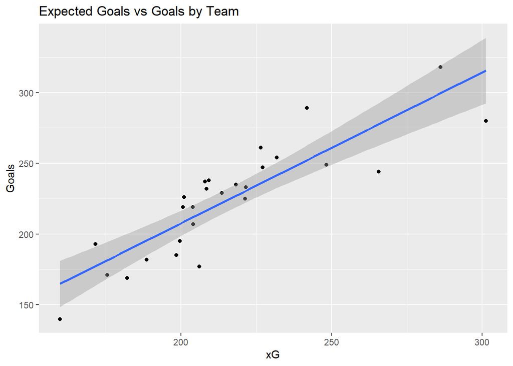

```r
ggplot(aes(x = xG, y = Goals), data = xg_team) +
    geom_point() +
    geom_smooth(method = 'lm') +
    labs(title = 'Expected Goals vs Goals by Team')
```

Next, the same by game, splitting the two teams. This will give us an idea of xg prediction vs actual goals per team.

```r
xg_game <- pbp_test %>%
    group_by(game_id, event_team) %>%
    summarise(xG = sum(xG), Goals = sum(is_goal), Difference = sum(xG) - sum(is_goal)) %>%
    arrange(desc(xG))
head(xg_game)
```

```
## # A tibble: 6 x 5
## # Groups:   game_id [6]
##   game_id    event_team    xG Goals Difference
##   <chr>      <chr>      <dbl> <dbl>      <dbl>
## 1 2019020176 VGK        10.8      5      5.84
## 2 2019020258 WSH         7.84     5      2.84
## 3 2019030121 T.B         6.69     3      3.69
## 4 2019020109 WSH         6.52     5      1.52
## 5 2019020221 OTT         6.34     6      0.342
## 6 2019020865 CGY         6.26     6      0.264
```

```r
game_xg <- lm(Goals ~ xG, data = xg_game)
summary(game_xg)
```

```
##
## Call:
## lm(formula = Goals ~ xG, data = xg_game)
##
## Residuals:
##     Min      1Q  Median      3Q     Max
## -4.6749 -1.1490 -0.1254  1.0406  5.5148
##
## Coefficients:
##             Estimate Std. Error t value Pr(>|t|)
## (Intercept)  1.12503    0.11104   10.13   <2e-16 ***
## xG           0.64726    0.03758   17.22   <2e-16 ***
## ---
## Signif. codes:  0 '***' 0.001 '**' 0.01 '*' 0.05 '.' 0.1 ' ' 1
##
## Residual standard error: 1.582 on 2368 degrees of freedom
##   (4 observations deleted due to missingness)
## Multiple R-squared:  0.1113, Adjusted R-squared:  0.1109
## F-statistic: 296.6 on 1 and 2368 DF,  p-value: < 2.2e-16
```

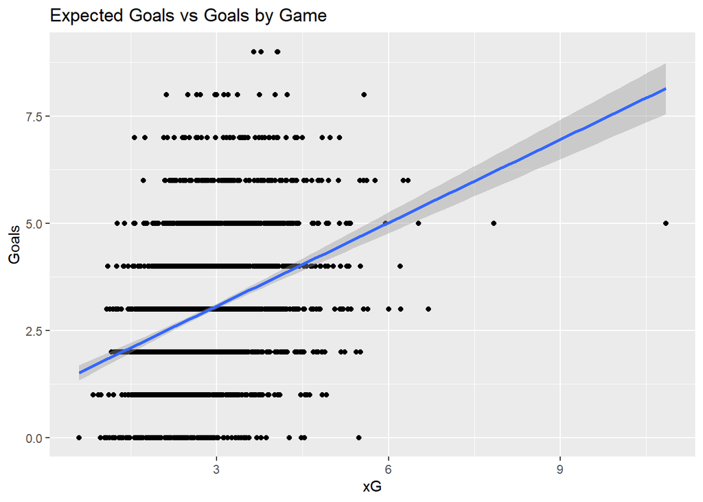

```r
ggplot(aes(x = xG, y = Goals), data = xg_game) +
    geom_point() +
    geom_smooth(method = 'lm') +
    labs(title = 'Expected Goals vs Goals by Game')
```

Lets look at the predictions of xG wins vs goal wins:

```r
xg_win <- pbp_test %>%
  group_by(game_id) %>%
  summarize(
    homeG = sum(is_goal[is_home == 1]),
    awayG = sum(is_goal[is_home == 0]),
    home_xg=sum(xG[is_home == 1]),
    away_xg=sum(xG[is_home == 0]),
    g_win=ifelse(homeG>awayG, 'home', 'away'),
    xg_win=ifelse(home_xg>away_xg, 'home', 'away'),
    agree=g_win==xg_win)
```